TLDR: Estimating the number of missing genes is hard.

There’s a huge debate going on right now about whether single cell data is zero-inflated or not. I’m going to add some of the lessons I learned over the course of my PhD in missing species/class problems. Estimating the number of missing species is hard. While models may seem close on the truncated, non-zero counts, the inferred number of missing zeros will be very far apart. Therefore, while it may seem that there is little difference between models with close fits, in practice that is not the case since a lot of downstream analyses depend heavily on good estimation of the the number of missing zeros.

First I’ll illustrate the underlying issue with some simple examples.

Let’s compare two cases: 1. Zero-Inflated Negative Binomial 2. Zero-Inflated log-Normal-Poisson

```r
set.seed(123)
n_genes = 20000
frac_missing = 0.75
dropout_indicator = rbinom(n_genes, size = 1, prob = frac_missing)
# using the fact that negative binomial is the same as Gamma-Poisson
m = 0.1
v = 5
lambdas = (1 - dropout_indicator)*m*rgamma(n_genes, shape = 1/v, scale = v)
zinb_counts = rpois(n_genes, lambda = lambdas)
print(paste0("fraction zero: ", sum(zinb_counts == 0)/n_genes))
```

```
## [1] "fraction zero: 0.9801"
```

```r
print(paste0("fraction dropped out: ", sum(dropout_indicator)/n_genes))
```

```
## [1] "fraction dropped out: 0.75335"
```

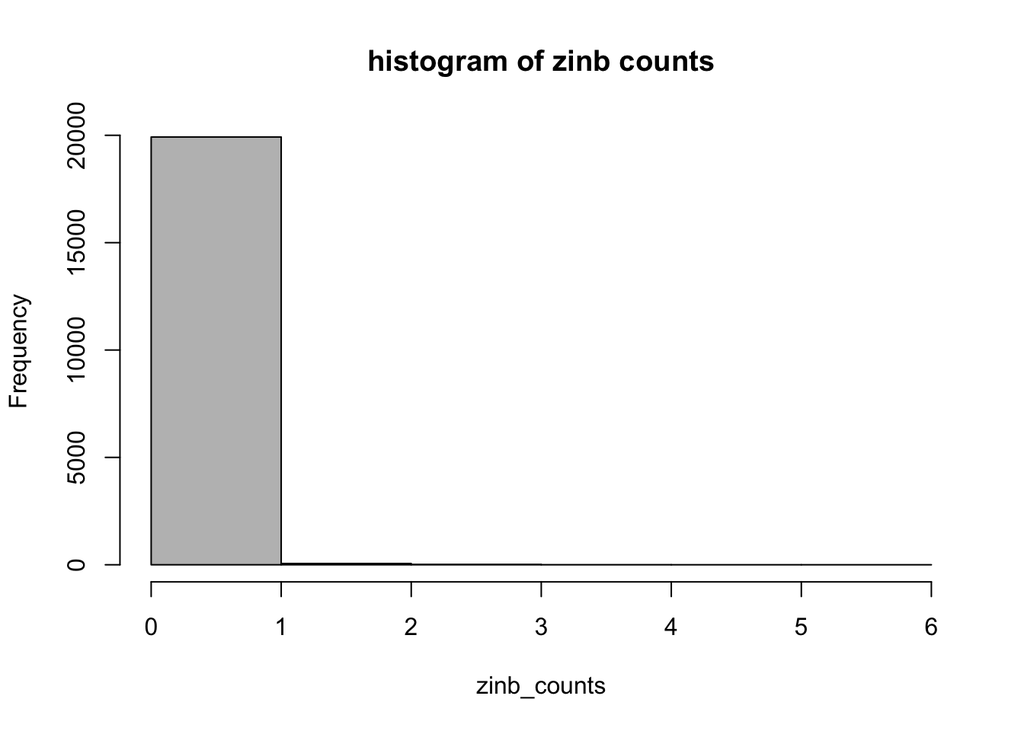

```r
hist(zinb_counts, col = "grey", main = "histogram of zinb counts", breaks = seq(from = 0, to = max(zinb_counts), by = 1))
```

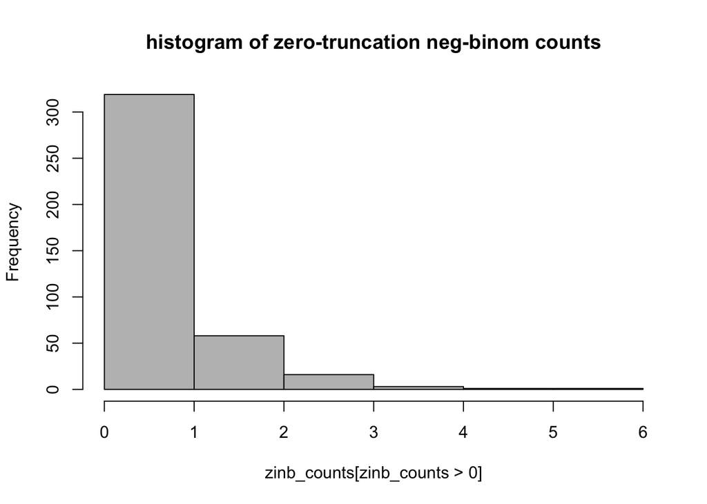

```r
hist(zinb_counts[zinb_counts > 0], col = "grey", main = "histogram of zero-truncation neg-binom counts",  breaks = seq(from = 0, to = max(zinb_counts), by = 1))
```

For comparison here’s zero-inflated log-normal Poisson counts. If we want to match the mean and variance above we note that the mean and variance of a log-normal random variable are $\text{exp}(\mu + \sigma^2/2)$ and $(\text{exp}(\sigma^2) - 1) \text{exp}(2 \mu + \sigma^2)$. Since the mean is 1, $\mu = -\sigma^2/2$.

```r
v = 5 # variance from above
sigma = sqrt(log(v + 1))
lambdas = m*exp(rnorm(n_genes, mean = -sigma^2/2, sd = sigma))
lambdas = (1 - dropout_indicator)*lambdas
zilnp_counts = rpois(n_genes, lambda = lambdas)
print(paste0("fraction zero: ", sum(zilnp_counts == 0)/n_genes))
```

```
## [1] "fraction zero: 0.9807"
```

```r
print(paste0("fraction dropped out: ", sum(dropout_indicator)/n_genes))
```

```
## [1] "fraction dropped out: 0.75335"
```

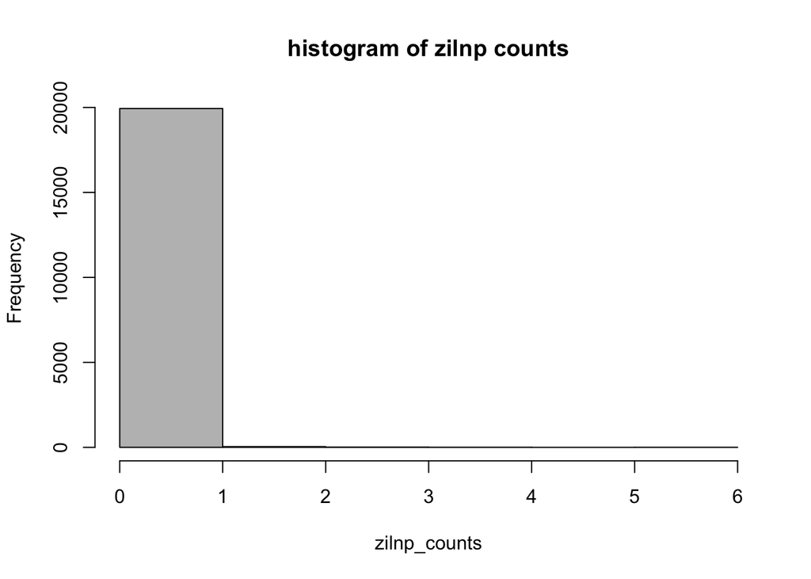

```r
hist(zilnp_counts, col = "grey", main = "histogram of zilnp counts", breaks = seq(from = 0, to = max(zilnp_counts), by = 1))
```

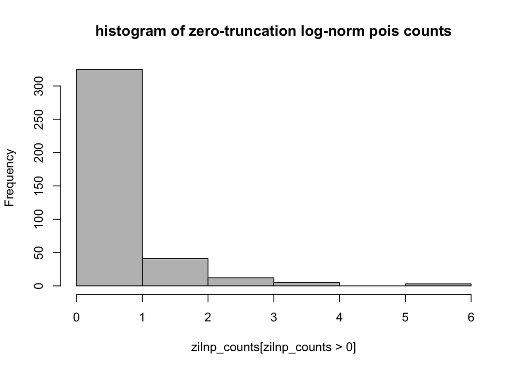

```r
hist(zilnp_counts[zilnp_counts > 0], col = "grey", main = "histogram of zero-truncation log-norm pois counts",  breaks = seq(from = 0, to = max(zilnp_counts), by = 1))
```

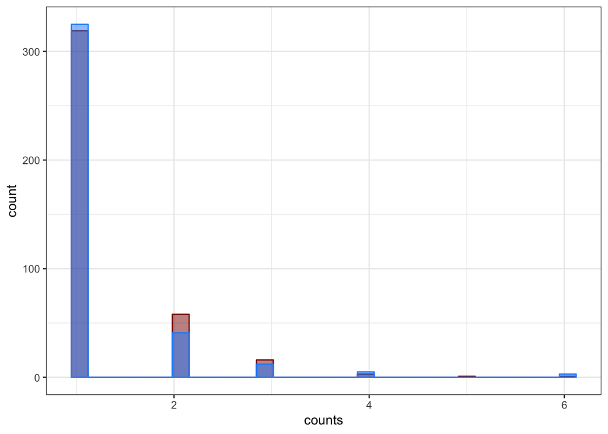

```r
library(ggplot2)
x = data.frame(counts = c(zinb_counts, zilnp_counts), model = rep(c("zinb", "zilnp"), each = n_genes))
x = x[which(x$counts > 0), ]
ggplot(x, aes(counts)) + geom_histogram(data = x[which(x$model == "zinb"), ], alpha = 0.5, col = "darkred", fill = "darkred") + geom_histogram(data = x[which(x$model == "zilnp"), ], alpha = 0.5, col = "dodgerblue", fill = "dodgerblue") + theme_bw()
```

Now, this matches the non-truncated mean and variances of the two distributions. What if we match the truncated means and variances?

We’ll work with the Gamma-Poisson parametrization of the Negative Binomial distribution for simplicity with shape = $k$ and scale = $\theta$. This has pmf
$$f_{\text{NB}}(x)= \int_{0}^{\infty} \frac{1}{\Gamma (k) \theta^{k}} \lambda^{k - 1} e^{-\lambda / \theta} \frac{1}{x!} \lambda^{x} e^{- \lambda} d \lambda = \frac{\Gamma(k + x)}{\Gamma(x + 1) \Gamma(k)} \theta^{x} (1 + \theta)^{-x - k}.$$
The zero-truncated Negative Binomial distribution has pmf
$$f_{\text{ZTNB}}(x) = \frac{1}{1 - (1 + \theta)^{-k}} \frac{\Gamma(k + x)}{\Gamma(x + 1) \Gamma(k)} \theta^{x} (1 + \theta)^{-x - k}.$$

The log-Normal Poisson has pmf
$$f_{\text{LNP}} (x) = \int_{0}^{\infty} \frac{1}{\lambda \sqrt{2 \pi \sigma^{2}}} \text{exp} \bigg( - \frac{(\log \lambda - \mu)^2}{2 \sigma^2} \bigg) \frac{1}{x!} \lambda^{x} e^{- \lambda} d \lambda.$$
As far as I know, there is no closed form to the above integral. See, for example, On Fitting the Poisson Lognormal Distribution to Species-Abundance Data. This puts mass at zero equal to
$$f_{\text{LNP}} (0) = \int_{0}^{\infty} \frac{1}{\lambda \sqrt{2 \pi \sigma^{2}}} \text{exp} \bigg( - \frac{(\log \lambda - \mu)^2}{2 \sigma^2} \bigg) e^{-\lambda} d \lambda.$$
Because of the complicated form of the above we won’t write out the full pmf of the zero-truncated form. We just note that it has the form
$$f_{\text{ZTLNP}}(x) = \frac{1}{1 - f_{\text{LNP}} (0)} f_{\text{LNP}}(0).$$
This has not closed form either, so we’ll do some approximate moment matching to compare the zero-truncated distributions. We’ll sample some negative binomial data, truncate the zeros, estimate the ZTLNP parameters, and finally sample LNP counts using the estimated parameters.

```r
ztnb_counts = zinb_counts[which(zinb_counts > 0)]
lnp_estimate = poilog::poilogMLE(ztnb_counts, zTrunc = TRUE)
lnp_estimate
```

```
## $par
##         mu        sig
## -1.8333122  0.9402778
##
## $p
## [1] 0.1955609
##
## $logLval
## [1] -261.303
##
## $gof
## NULL
##
## $boot
## NULL
```

```r
D = length(ztnb_counts)
# horvitz-thompson estimator: N = D/(1 - Pr(0))
N_lnp = D/(1 - poilog::dpoilog(0, mu = lnp_estimate$par['mu'], sig = lnp_estimate$par['sig']))
N_lnp
```

```
## [1] 2035.172
```

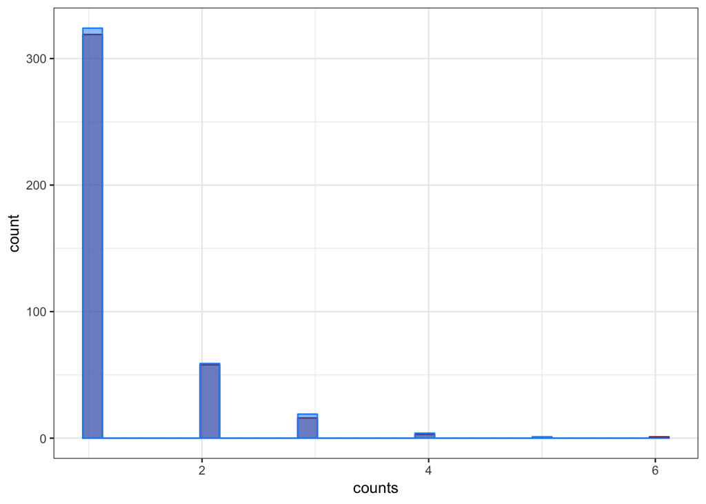

```r
ztlnp_counts = poilog::rpoilog(S = as.integer(N_lnp), mu = lnp_estimate$par['mu'],
                             sig = lnp_estimate$par['sig'])
x = data.frame(counts = c(ztnb_counts, ztlnp_counts),
               model = c(rep("ztnb", times = length(ztnb_counts)),
                         rep("ztlnp", times = length(ztlnp_counts))))
ggplot(x, aes(counts)) + geom_histogram(data = x[which(x$model == "ztnb"), ], alpha = 0.5, col = "darkred", fill = "darkred") + geom_histogram(data = x[which(x$model == "ztlnp"), ], alpha = 0.5, col = "dodgerblue", fill = "dodgerblue") + theme_bw()
```

Let’s look at difference between the number of non-zero genes between these two.

```r
N_lnp
```

```
## [1] 2035.172
```

```r
N_nb = sum(lambdas > 0)
N_nb
```

```
## [1] 4933
```

Now, let’s take a look at how good model selection is here. This is a proxy for the truth. The parametric model (without good theoretical reason) is most often wrong, but even when it is wrong, the model selection has a profound impact on the estimated zero-inflation. Let’s look at how often model selection is right (out of only 2 choices), and what impact this has on the estimated zero-inlfation.

```r
n_sims = 200
ztnb_sim_estimates = data.frame(ztnb_N = rep(0, times = n_sims),
                                ztlnp_N = rep(0, times = n_sims),
                                ztnb_log_like = rep(0, times = n_sims),
                                ztlnp_log_like = rep(0, times = n_sims))
for(i in 1:n_sims){
  n_genes = 5000
  lambdas = m*rgamma(n_genes, shape = 1/v, scale = v)
  nb_counts = rpois(n_genes, lambda = lambdas)
  ztnb_counts = nb_counts[which(nb_counts > 0)]
  poilogFit = poilog::poilogMLE(ztnb_counts)
  ztnb_hist = data.frame(j = sort(unique(ztnb_counts), decreasing = FALSE),
                         n_j = sapply(sort(unique(ztnb_counts), decreasing = FALSE),
                                      function(t) sum(ztnb_counts == t)))
  ztnbfit = preseqR::preseqR.ztnb.em(ztnb_hist)
  ztnb_sim_estimates$ztnb_log_like[i] = ztnbfit$loglik
  ztnb_sim_estimates$ztlnp_log_like[i] = poilogFit$logLval
  D = length(ztnb_counts)
  ztnb_sim_estimates$ztnb_N[i] = as.integer(D/(1 - dnbinom(0, mu = ztnbfit$mu, size = ztnbfit$size)))
  ztnb_sim_estimates$ztlnp_N[i] = as.integer(D/(1 - poilog::dpoilog(0, mu = poilogFit$par["mu"], sig = poilogFit$par["sig"])))
}
ztnb_sim_estimates = data.frame(ztnb_sim_estimates,
                                N_diff = ztnb_sim_estimates$ztnb_N -
                                  ztnb_sim_estimates$ztlnp_N,
                                log_like_diff = ztnb_sim_estimates$ztnb_log_like -
                                  ztnb_sim_estimates$ztlnp_log_like)
head(ztnb_sim_estimates)
```

```
##   ztnb_N ztlnp_N ztnb_log_like ztlnp_log_like N_diff log_like_diff
## 1   5108    1890     -276.8938      -276.7753   3218  -0.118491517
## 2    928     894     -243.0497      -243.0589     34   0.009251834
## 3   1375     854     -243.8547      -245.4258    521   1.571091115
## 4   3032    1026     -241.6268      -244.9271   2006   3.300350314
## 5 153672    1145     -245.2788      -253.4457 152527   8.166878728
## 6   1794    1064     -244.1305      -245.6916    730   1.561096250
```

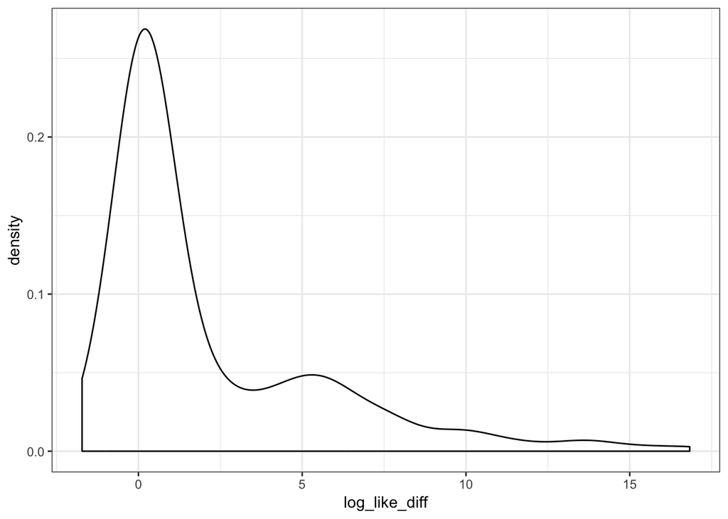

```r
ggplot(ztnb_sim_estimates, aes(x = log_like_diff)) + geom_density() + theme_bw()
```

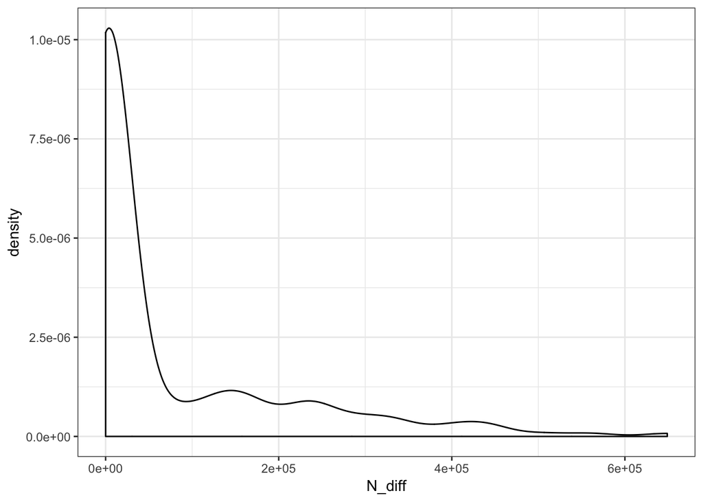

```r
ggplot(ztnb_sim_estimates, aes(x = N_diff)) + geom_density() + theme_bw()
```

```r
# fraction of model mis-selection
sum(ztnb_sim_estimates$log_like_diff < 0)/n_sims
```

```
## [1] 0.185
```

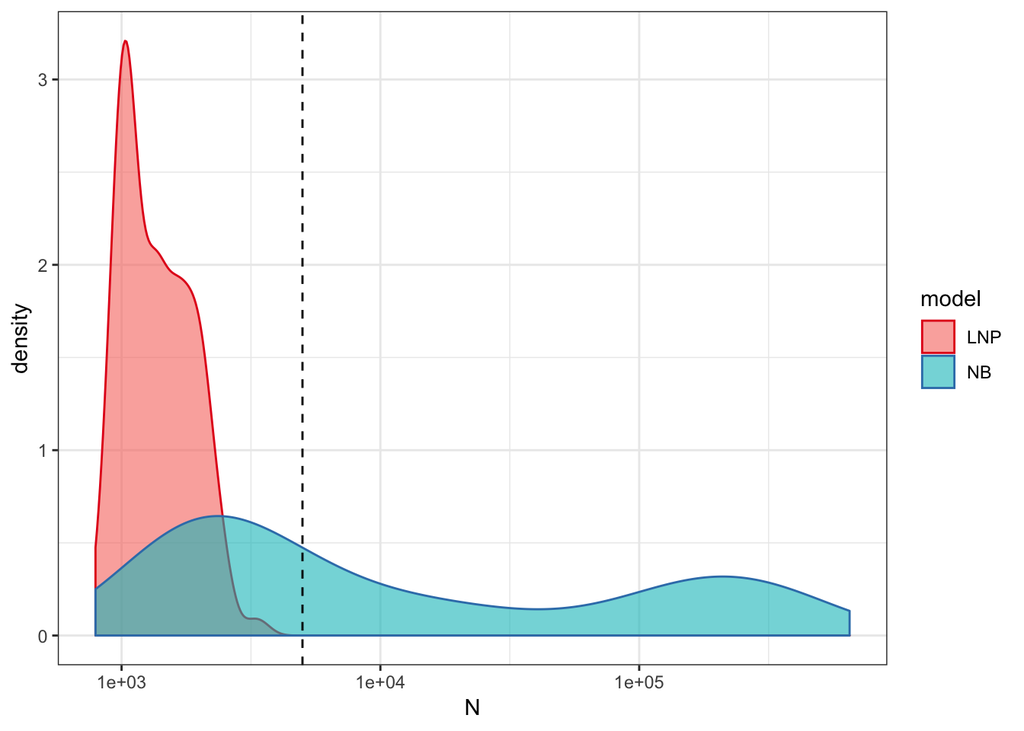

```r
N = data.frame(N = c(ztnb_sim_estimates$ztnb_N, ztnb_sim_estimates$ztlnp_N),
               model = rep(c("NB", "LNP"), each = dim(ztnb_sim_estimates)[1]))
ggplot(N, aes(x = N, col = model, fill = model)) + geom_density(alpha = 0.6) + geom_vline(xintercept = n_genes, lty = 2) + scale_x_log10() + scale_color_brewer(palette = 'Set1') + theme_bw()
```

```r
n_sims = 100
m = 0.2
var_param = 1:8
model_sel = data.frame(var_param = var_param,
                       frac_correct = rep(0, times = length(var_param)))
for(i in 1:length(var_param)){
  n_correct = 0
  v = var_param[i]
  for(j in 1:n_sims){
    n_genes = 5000
    lambdas = m*rgamma(n_genes, shape = 1/v, scale = v)
    nb_counts = rpois(n_genes, lambda = lambdas)
    ztnb_counts = nb_counts[which(nb_counts > 0)]
    poilogFit = poilog::poilogMLE(ztnb_counts)
    ztnb_hist = data.frame(j = sort(unique(ztnb_counts), decreasing = FALSE),
                           n_j = sapply(sort(unique(ztnb_counts), decreasing = FALSE),
                                        function(t) sum(ztnb_counts == t)))
    ztnbfit = preseqR::preseqR.ztnb.em(ztnb_hist)
    if(ztnbfit$loglik > poilogFit$logLval){
      n_correct = n_correct + 1
    }
  }
  model_sel$frac_correct[i] = n_correct/n_sims
}
model_sel
```

```
##   var_param frac_correct
## 1         1         0.72
## 2         2         0.68
## 3         3         0.72
## 4         4         0.74
## 5         5         0.85
## 6         6         0.74
## 7         7         0.70
## 8         8         0.82
```

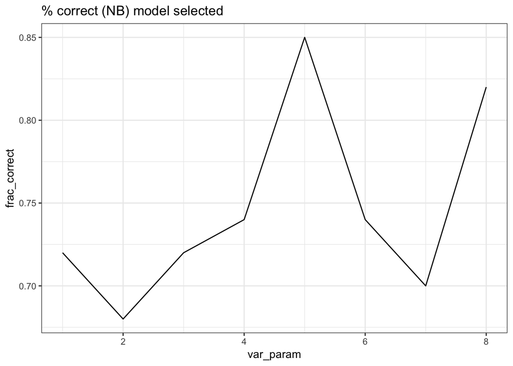

```r
ggplot(model_sel, aes(x = var_param, y = frac_correct)) + geom_line() + theme_bw() + ggtitle('% correct (NB) model selected')
```